# HT05

2023-04-14

[output not shown]

[output not shown]

# Hoja de Trabajo 06 - Regresión Logística

## 1 - Crear una variable dicotómica por cada una de las categorías de la variable respuesta categórica que creó en hojas anteriores. Debería tener 3 variables dicotómicas.

### Limpiando los datos

Columnas a utilizar (basándonos en el análisis exploratorio de la hoja anterior):

```r
print(paste(columns_used,collapse=' '))
```

```
## [1] "neighborhood houseStyle houseZone houseUtilities roadAccess remodelated roofStyle roofMaterial overallQuality overallCondition exteriorCondition foundationMaterial basement basementCondition fireplace garageArea pool additionalFeature livingArea yearBuilt salePrice saleType mSZoning"
```

Volviendo a usar la variable categorica

```r
clean_data$economy <- ifelse(clean_data$salePrice < 163000, "Economic", ifelse(clean_data$salePrice >= 163000 & clean_data$salePrice <= 214000, "Average", "Expensive"))
```

```r
clean_data <- dummy_cols(clean_data, select_columns = "economy", remove_selected_columns = TRUE)
head(clean_data)
```

```
##   neighborhood houseStyle houseZone houseUtilities roadAccess remodelated
## 1            9          2         6              1          3           0
## 2            5          1         6              1          2           0
## 3            9          2         6              1          3           1
## 4            8          2         6              1          3           1
## 5            1          2         6              1          3           0
## 6           14          3         6              1          3           1
##   roofStyle roofMaterial overallQuality overallCondition exteriorCondition
## 1         2            2              7                5                 3
## 2         2            2              6                8                 3
## 3         2            2              7                5                 3
## 4         2            2              7                5                 3
## 5         2            2              8                5                 3
## 6         2            2              5                5                 3
##   foundationMaterial basement basementCondition fireplace garageArea pool
```

[output cut: 20 more lines]

## 2 - Use los mismos conjuntos de entrenamiento y prueba que utilizó en las hojas anteriores.

Un 75% del dataset se usará para entrenar el árbol.

```r
clean_data[!complete.cases(clean_data$salePrice), "salePrice"]<-median(clean_data$salePrice, na.rm = T)
```

```r
clean_data <- na.omit(clean_data)
```

```r
threshold <- 394950
clean_data$pricey <- ifelse(clean_data$salePrice > threshold, 1, 0)
```

```r
set.seed(5)
expected_result <- clean_data$salePrice
partition <- createDataPartition(y=expected_result,
                                 p=.75,
                                 list=F)
train_set <- clean_data[partition,]
test_set <- clean_data[-partition,]
```

## 3 - Elabore un modelo de regresión logística para conocer si una vivienda es cara o no, utilizando el conjunto de entrenamiento. Use validación cruzada.

```r
ctrlspecs <- trainControl(method="cv",
                          number=10,
                          savePredictions="all",
                          )
model1 <- caret::train(
  pricey ~ economy_Average + economy_Economic + economy_Expensive,
  data = train_set,
  method = "glm",
  family = binomial,
  trControl = ctrlspecs
)

summary(model1)
```

```
##
## Call:
## NULL
##
## Deviance Residuals:
##      Min        1Q    Median        3Q       Max
## -0.42445  -0.00003  -0.00003  -0.00003   2.21439
##
## Coefficients: (1 not defined because of singularities)
##                    Estimate Std. Error z value Pr(>|z|)
## (Intercept)         -2.3617     0.2181 -10.827   <2e-16 ***
## economy_Average    -19.2044  1762.7824  -0.011    0.991
## economy_Economic   -19.2044  1279.4691  -0.015    0.988
## economy_Expensive        NA         NA      NA       NA
## ---
## Signif. codes:  0 '***' 0.001 '**' 0.01 '*' 0.05 '.' 0.1 ' ' 1
##
## (Dispersion parameter for binomial family taken to be 1)
##
##     Null deviance: 221.88  on 1063  degrees of freedom
## Residual deviance: 156.74  on 1061  degrees of freedom
## AIC: 162.74
##
## Number of Fisher Scoring iterations: 20
```

## 4 - Analizando el modelo

La variable economic_Expensive no tiene un valor para los errores estimados y estándar, por lo que la podemos descartar como una variable significativa. Utilizamos la matriz de correlación para determinar la multicolinealidad.

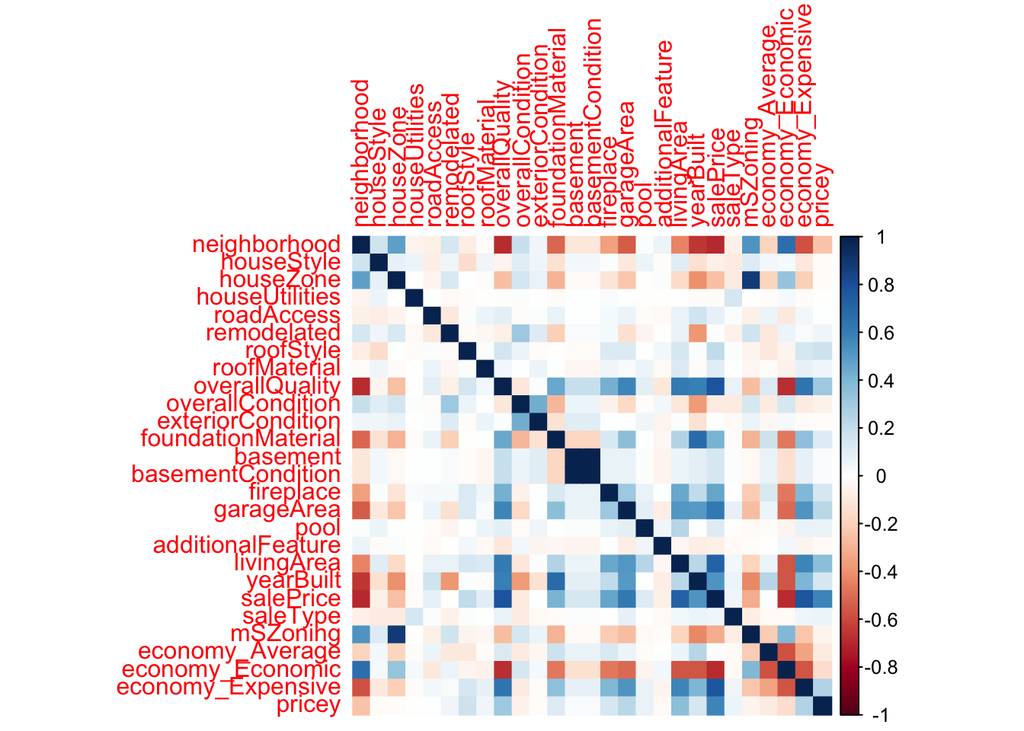

```r
corr_matrix <- cor(train_set)
corrplot(corr_matrix, method = "color")
```

Al observar esta imagen podemos ver que hay una alta correlación entre las variables predictoras del modelo.

## 5 - Utilice el modelo con el conjunto de prueba y determine la eficiencia del algoritmo para clasificar

```r
pred <- predict(model1, newdata = test_set[,-1])
head(pred)
```

```
##            1            6            8           12           13           15
## 4.305023e-10 4.305023e-10 4.305023e-10 8.614232e-02 4.305023e-10 4.305023e-10
```

```r
binary_predictions <- ifelse(pred > 0.5, 1, 0)

caret::confusionMatrix(as.factor(binary_predictions), as.factor(test_set$pricey))
```

```
## Confusion Matrix and Statistics
##
##           Reference
## Prediction   0   1
##          0 348   6
##          1   0   0
##
##                Accuracy : 0.9831
##                  95% CI : (0.9635, 0.9938)
##     No Information Rate : 0.9831
##     P-Value [Acc > NIR] : 0.60631
##
##                   Kappa : 0
##
##  Mcnemar's Test P-Value : 0.04123
##
##             Sensitivity : 1.0000
##             Specificity : 0.0000
##          Pos Pred Value : 0.9831
##          Neg Pred Value :    NaN
##              Prevalence : 0.9831
##          Detection Rate : 0.9831
##    Detection Prevalence : 1.0000
##       Balanced Accuracy : 0.5000
##
##        'Positive' Class : 0
##
```

## 6 - Demostrar si hay overfitting o no

```r
train_set$pricey <- as.factor(train_set$pricey)
house_task = makeClassifTask(data = train_set, target = "pricey")
rin2 = makeResampleDesc(method = "CV", iters = 10, predict = "both")
lrn = makeLearner("classif.multinom", predict.type = "prob", trace = FALSE)
```